# Lab week 10 - Tree-based methods

Data Science and Machine Learning 2 - CEU 2018

Jeno Pal

2018-03-06

```r
library(data.table)
library(caret)
library(rpart)
library(rpart.plot)
library(xgboost)
library(randomForest)
library(gbm)
library(ISLR)
library(skimr)
```

## Bagging, random forests

We covered decision trees in DS-ML-1. Using it as a base model lets us build many different models with less variance and better predictive power. The downside: interpretation gets harder.

Idea: as individual trees are unstable and have high variance, train many versions on bootstrap samples (“Bagging”: Bootstrap AGGregation). Then predict: take the average (regression), majority vote / class share (classification).

Random forests: randomly constrain the set of predictor variables used to grow trees. Goal: avoid correlated trees that are very similar to each other, still with the aim of decreasing variance.

```r
data(Hitters)
data <- data.table(Hitters)
skim(data)
```

|  | variable | type | stat | level | value | formatted |
| --- | --- | --- | --- | --- | --- | --- |
| 1 | AtBat | integer | missing | .all | 0.000000 | 0 |
| 2 | AtBat | integer | complete | .all | 322.000000 | 322 |
| 3 | AtBat | integer | n | .all | 322.000000 | 322 |
| 4 | AtBat | integer | mean | .all | 380.928571 | 380.93 |
| 5 | AtBat | integer | sd | .all | 153.404981 | 153.4 |
| 6 | AtBat | integer | p0 | .all | 16.000000 | 16 |
| 7 | AtBat | integer | p25 | .all | 255.250000 | 255.25 |
| 8 | AtBat | integer | median | .all | 379.500000 | 379.5 |
| 9 | AtBat | integer | p75 | .all | 512.000000 | 512 |
| 10 | AtBat | integer | p100 | .all | 687.000000 | 687 |

[output cut: 201 more lines]

```r
# goal: predict log salary
data <- data[!is.na(Salary)]
data[, log_salary := log(Salary)]
data[, Salary := NULL]
```

```r
training_ratio <- 0.75
set.seed(1234)
train_indices <- createDataPartition(y = data[["log_salary"]],
                                     times = 1,
                                     p = training_ratio,
                                     list = FALSE)
data_train <- data[train_indices, ]
data_test <- data[-train_indices, ]
```

Let’s see benchmarks: a linear model and a simple regression tree.

```r
train_control <- trainControl(method = "repeatedcv",
                              number = 5,
                              repeats = 3)

set.seed(857)
linear_model <- train(log_salary ~ .,
                      method = "lm",
                      data = data_train,
                      trControl = train_control)
linear_model
```

```
## Linear Regression
##
## 200 samples
##  19 predictor
##
## No pre-processing
## Resampling: Cross-Validated (5 fold, repeated 3 times)
## Summary of sample sizes: 160, 160, 160, 159, 161, 162, ...
## Resampling results:
##
##   RMSE       Rsquared   MAE
##   0.7039273  0.4071298  0.5665639
##
## Tuning parameter 'intercept' was held constant at a value of TRUE
```

```r
set.seed(857)
simple_tree_model <- train(log_salary ~ .,
                      method = "rpart",
                      data = data_train,
                      tuneGrid = data.frame(cp = c(0.01, 0.02, 0.05)),
                      trControl = train_control)
simple_tree_model
```

```
## CART
##
## 200 samples
##  19 predictor
##
## No pre-processing
## Resampling: Cross-Validated (5 fold, repeated 3 times)
## Summary of sample sizes: 160, 160, 160, 159, 161, 162, ...
## Resampling results across tuning parameters:
##
##   cp    RMSE       Rsquared   MAE
##   0.01  0.5553964  0.6201776  0.4124635
##   0.02  0.5387555  0.6405251  0.4009572
##   0.05  0.5966238  0.5666164  0.4474878
##
## RMSE was used to select the optimal model using the smallest value.
## The final value used for the model was cp = 0.02.
```

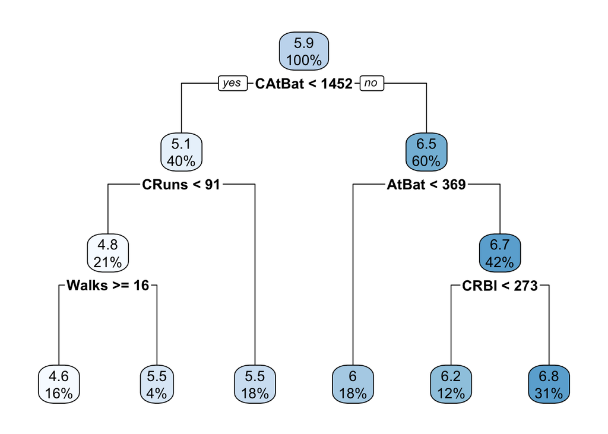

```r
rpart.plot(simple_tree_model[["finalModel"]])
```

For random forests, `mtry` sets the number of variables randomly chosen for a tree. When `mtry` equals the number of features, it is the bagging.

```r
# random forest
set.seed(857)
rf_model <- train(log_salary ~ .,
                  method = "rf",
                  data = data_train,
                  trControl = train_control,
                  tuneGrid = data.frame(mtry = c(2, 3, 5, 7, 9, 12, 19)),
                  importance = T # to calculate variable importance measures
                  )
rf_model
```

```
## Random Forest
##
## 200 samples
##  19 predictor
##
## No pre-processing
## Resampling: Cross-Validated (5 fold, repeated 3 times)
## Summary of sample sizes: 160, 160, 160, 159, 161, 162, ...
## Resampling results across tuning parameters:
##
##   mtry  RMSE       Rsquared   MAE
##    2    0.4581976  0.7404439  0.3274967
##    3    0.4567935  0.7395250  0.3257100
##    5    0.4588722  0.7374492  0.3278753
##    7    0.4618586  0.7343766  0.3309580
##    9    0.4679288  0.7275473  0.3358942
##   12    0.4682094  0.7273121  0.3365402
##   19    0.4795420  0.7147787  0.3454379
##
## RMSE was used to select the optimal model using the smallest value.
## The final value used for the model was mtry = 3.
```

```r
# the number of trees is not a tuning parameter with caret
# default is 500, you can change it with passing the parameter to train
set.seed(857)
rf_model_ntree_10 <- train(log_salary ~ .,
                  method = "rf",
                  data = data_train,
                  trControl = train_control,
                  tuneGrid = data.frame(mtry = c(2, 3, 5)),
                  ntree = 10,
                  importance = T # to calculate variable importance measures
                  )
rf_model_ntree_10
```

```
## Random Forest
##
## 200 samples
##  19 predictor
##
## No pre-processing
## Resampling: Cross-Validated (5 fold, repeated 3 times)
## Summary of sample sizes: 160, 160, 160, 159, 161, 162, ...
## Resampling results across tuning parameters:
##
##   mtry  RMSE       Rsquared   MAE
##   2     0.4854403  0.7058451  0.3562275
##   3     0.4843892  0.7117096  0.3467226
##   5     0.4915282  0.6969564  0.3511114
##
## RMSE was used to select the optimal model using the smallest value.
## The final value used for the model was mtry = 3.
```

```r
# calculate test error
RMSE <- function(x, true_x) sqrt(mean((x - true_x)^2))

RMSE(data_test[["log_salary"]], predict.train(rf_model, newdata = data_test))
```

```
## [1] 0.3658367
```

(It is a small dataset hence performance measures can have large variances.)

### Variable importance

With the ensemble models we have a hard time with interpretation. Variable importance measures can help to see which features contribute most to the predictive power of models. The generic `varImp` function of `caret` does model-specific calculations, consult [here](https://topepo.github.io/caret/variable-importance.html) for a description for your model at hand.

```r
varImp(rf_model)
```

```
## rf variable importance
##
##            Overall
## CHits      100.000
## CAtBat      98.638
## CRuns       92.427
## CRBI        89.339
## CWalks      81.398
## Years       76.555
## CHmRun      62.081
## Hits        61.772
## AtBat       61.752
## Walks       58.723
## Runs        54.290
## RBI         50.701
## HmRun       27.186
## PutOuts     18.721
## Assists     13.758
## Errors      10.504
## LeagueN     10.123
## NewLeagueN   5.507
## DivisionW    0.000
```

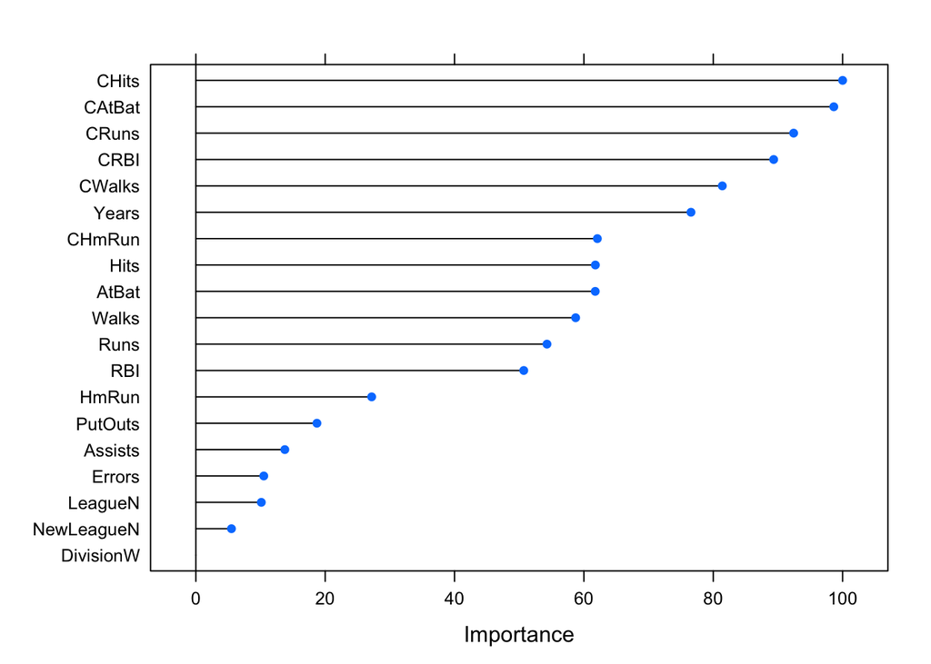

```r
plot(varImp(rf_model))
```

## Gradient boosting machines

Gradient boosting machines: also ensembles of trees, however, the method of choosing them is different. Idea: get the residual and train next tree to predict (explain) the residual. Then add it to the previous trees, with a shrinkage parameter (to avoid overfitting).

Another difference: GBMs use shallow trees (controlled by `interaction.depth`) whereas RFs use unpruned, large trees (with low bias and high variance). Common part: idea of bagging.

```r
gbm_grid <- expand.grid(n.trees = c(100, 500, 1000),
                        interaction.depth = c(2, 3, 5),
                        shrinkage = c(0.005, 0.01, 0.1),
                        n.minobsinnode = c(5))

gbm_model <- train(log_salary ~ .,
                   method = "gbm",
                   data = data_train,
                   trControl = train_control,
                   tuneGrid = gbm_grid,
                   verbose = FALSE # gbm by default prints too much output
                   )
gbm_model
```

```
## Stochastic Gradient Boosting
##
## 200 samples
##  19 predictor
##
## No pre-processing
## Resampling: Cross-Validated (5 fold, repeated 3 times)
## Summary of sample sizes: 160, 160, 160, 159, 161, 160, ...
## Resampling results across tuning parameters:
##
##   shrinkage  interaction.depth  n.trees  RMSE       Rsquared   MAE
##   0.005      2                   100     0.6923118  0.6735517  0.5654157
##   0.005      2                   500     0.4951795  0.7064150  0.3666764
##   0.005      2                  1000     0.4705642  0.7180090  0.3399538
##   0.005      3                   100     0.6789284  0.6911265  0.5555834
##   0.005      3                   500     0.4829688  0.7140680  0.3539325
##   0.005      3                  1000     0.4651613  0.7226436  0.3339962
##   0.005      5                   100     0.6682785  0.7051202  0.5508453
##   0.005      5                   500     0.4721488  0.7213127  0.3435339
##   0.005      5                  1000     0.4607437  0.7259815  0.3322401
##   0.010      2                   100     0.5892493  0.6881479  0.4688317
##   0.010      2                   500     0.4674916  0.7219420  0.3383068
##   0.010      2                  1000     0.4664559  0.7208400  0.3389193
##   0.010      3                   100     0.5740747  0.6995723  0.4561875
##   0.010      3                   500     0.4655539  0.7227604  0.3331341
##   0.010      3                  1000     0.4684287  0.7186931  0.3395480
##   0.010      5                   100     0.5589451  0.7102800  0.4458378
##   0.010      5                   500     0.4636138  0.7221337  0.3348493
##   0.010      5                  1000     0.4657418  0.7208362  0.3422567
##   0.100      2                   100     0.4807943  0.7030254  0.3521890
##   0.100      2                   500     0.5001783  0.6866457  0.3704305
##   0.100      2                  1000     0.5075889  0.6802814  0.3776175
##   0.100      3                   100     0.4789480  0.7075714  0.3531689
##   0.100      3                   500     0.5038655  0.6837644  0.3790731
##   0.100      3                  1000     0.5073984  0.6810269  0.3822283
##   0.100      5                   100     0.4811531  0.7062927  0.3584559
##   0.100      5                   500     0.4909099  0.6987888  0.3758415
##   0.100      5                  1000     0.4908954  0.6990904  0.3763060
##
## Tuning parameter 'n.minobsinnode' was held constant at a value of 5
## RMSE was used to select the optimal model using the smallest value.
## The final values used for the model were n.trees = 1000,
##  interaction.depth = 5, shrinkage = 0.005 and n.minobsinnode = 5.
```

4 hyperparameters: [the curse of dimensionality](https://en.wikipedia.org/wiki/Curse_of_dimensionality) can make it hard to come up with efficient grids for hyperparameter search. However, with `gbm` and many other models, in reality the models to be estimated are not exponentially growing with the number of hyperparameters (see [here](https://topepo.github.io/caret/random-hyperparameter-search.html)).

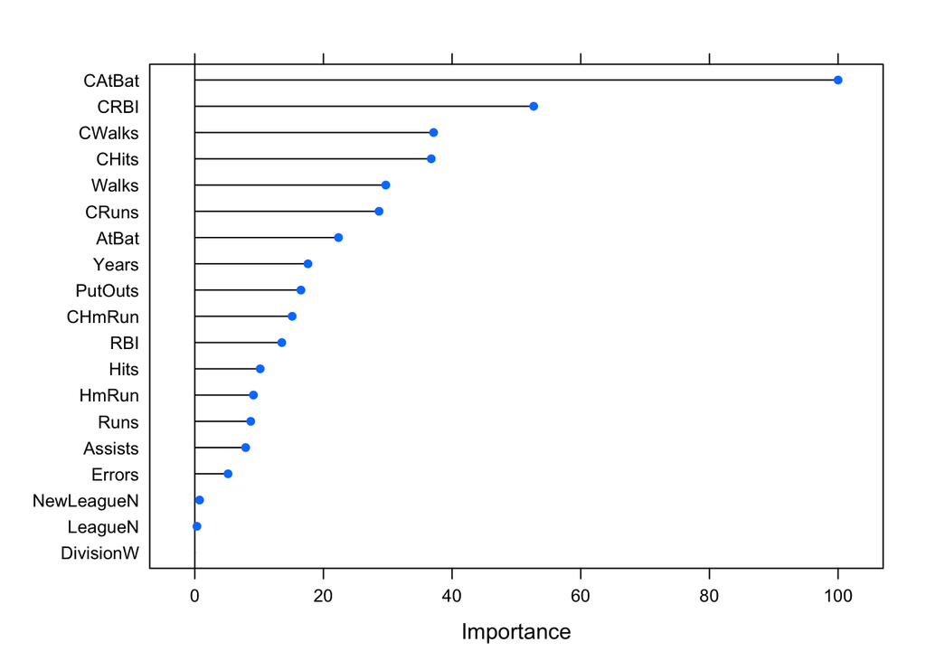

```r
plot(varImp(gbm_model))
```

Lower `eta` means slower learning, hence more trees are necessary to have good performance.

Not tuned: `bag.fraction` parameter (set to default 0.5): for the construction of each tree, only `bag.fraction` share of the sample is used (randomly selected, see `?gbm`). This, again, is the same idea as with bagging: decrease variance of the model. You can pass another value for it via giving `train` an argument `bag.fraction`, just like we saw with `rf` and `ntree`.

```r
gbm_grid_2 <- data.frame(n.trees = c(1000),
                         interaction.depth = c(5),
                         shrinkage = c(0.005),
                         n.minobsinnode = c(5))

gbm_model_2 <- train(log_salary ~ .,
                   method = "gbm",
                   data = data_train,
                   trControl = train_control,
                   tuneGrid = gbm_grid_2,
                   bag.fraction = 0.8,
                   verbose = FALSE # gbm by default prints too much output
                   )
gbm_model_2
```

```
## Stochastic Gradient Boosting
##
## 200 samples
##  19 predictor
##
## No pre-processing
## Resampling: Cross-Validated (5 fold, repeated 3 times)
## Summary of sample sizes: 160, 160, 160, 160, 160, 162, ...
## Resampling results:
##
##   RMSE       Rsquared   MAE
##   0.4937827  0.6922357  0.3608963
##
## Tuning parameter 'n.trees' was held constant at a value of 1000
##  5
## Tuning parameter 'shrinkage' was held constant at a value of
##  0.005
## Tuning parameter 'n.minobsinnode' was held constant at a value of 5
```

### XGBoost

A celebrated implementation of the gradient boosting idea. *“Both xgboost and gbm follows the principle of gradient boosting. There are however, the difference in modeling details. Specifically, xgboost used a more regularized model formalization to control over-fitting, which gives it better performance.”*

See documentation [here](http://xgboost.readthedocs.io/). It proved to be very stable and widely applicable. For the many hyperparameters, consult the documentation.

```r
xgbGrid <- expand.grid(nrounds = c(500, 1000),
                       max_depth = c(2, 3, 5),
                       eta = c(0.01, 0.05),
                       gamma = 0,
                       colsample_bytree = c(0.5, 0.7),
                       min_child_weight = 1,
                       subsample = c(0.5))
set.seed(857)
xgboost_model <- train(log_salary ~ .,
                       method = "xgbTree",
                       data = data_train,
                       trControl = train_control,
                       tuneGrid = xgbGrid)
xgboost_model
```

```
## eXtreme Gradient Boosting
##
## 200 samples
##  19 predictor
##
## No pre-processing
## Resampling: Cross-Validated (5 fold, repeated 3 times)
## Summary of sample sizes: 160, 160, 160, 159, 161, 162, ...
## Resampling results across tuning parameters:
##
##   eta   max_depth  colsample_bytree  nrounds  RMSE       Rsquared
##   0.01  2          0.5                500     0.4887984  0.7066260
##   0.01  2          0.5               1000     0.4767010  0.7151926
##   0.01  2          0.7                500     0.4831342  0.7125804
##   0.01  2          0.7               1000     0.4679866  0.7256519
##   0.01  3          0.5                500     0.4871736  0.7076095
##   0.01  3          0.5               1000     0.4718172  0.7210254
##   0.01  3          0.7                500     0.4822084  0.7163536
##   0.01  3          0.7               1000     0.4623150  0.7336332
##   0.01  5          0.5                500     0.4917052  0.7054442
##   0.01  5          0.5               1000     0.4775463  0.7155994
##   0.01  5          0.7                500     0.4853183  0.7152446
##   0.01  5          0.7               1000     0.4658930  0.7310880
##   0.05  2          0.5                500     0.4818326  0.7115343
##   0.05  2          0.5               1000     0.4906633  0.7019562
##   0.05  2          0.7                500     0.4721905  0.7230970
##   0.05  2          0.7               1000     0.4779579  0.7176813
##   0.05  3          0.5                500     0.4752795  0.7184832
##   0.05  3          0.5               1000     0.4791130  0.7148925
##   0.05  3          0.7                500     0.4656422  0.7302949
##   0.05  3          0.7               1000     0.4680977  0.7274879
##   0.05  5          0.5                500     0.4807550  0.7130878
##   0.05  5          0.5               1000     0.4812718  0.7125615
##   0.05  5          0.7                500     0.4778057  0.7169084
##   0.05  5          0.7               1000     0.4780605  0.7166600
##   MAE
##   0.3532002
##   0.3431200
##   0.3471703
##   0.3353595
```

[output cut: 15 more lines]

```
##   0.3431617
##   0.3522483
##   0.3529059
##   0.3468194
##   0.3471710
##
## Tuning parameter 'gamma' was held constant at a value of 0
##
## Tuning parameter 'min_child_weight' was held constant at a value of
##  1
## Tuning parameter 'subsample' was held constant at a value of 0.5
## RMSE was used to select the optimal model using the smallest value.
## The final values used for the model were nrounds = 1000, max_depth =
##  3, eta = 0.01, gamma = 0, colsample_bytree = 0.7, min_child_weight =
##  1 and subsample = 0.5.
```

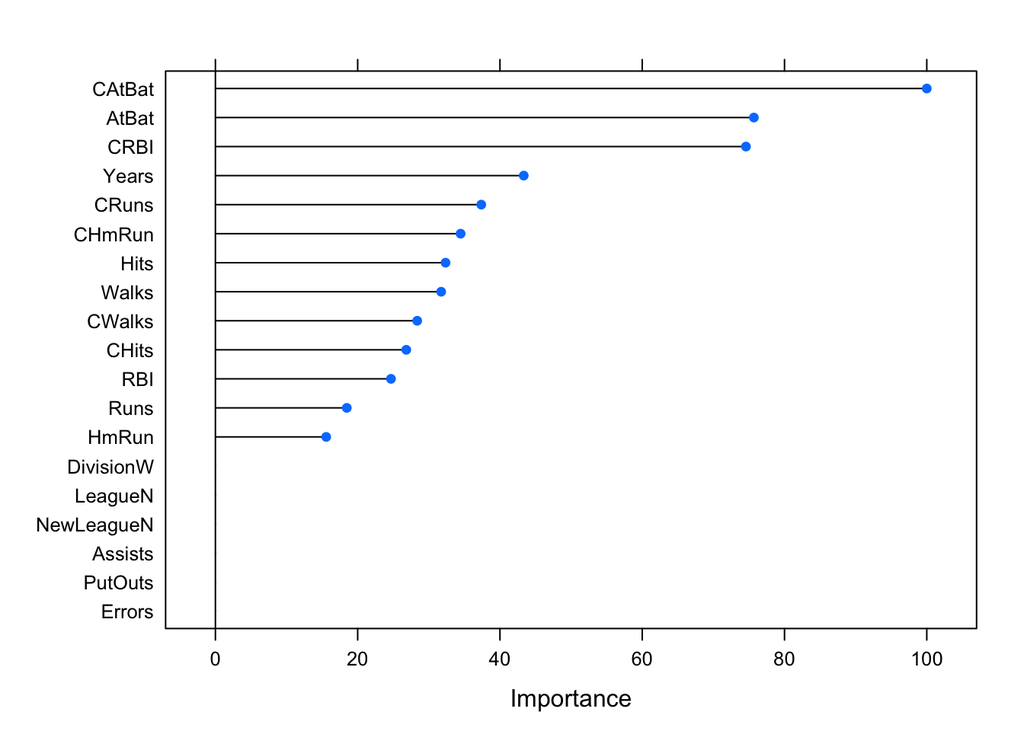

```r
plot(varImp(xgboost_model))
```

```r
resamples_object <- resamples(list("rpart" = simple_tree_model,
                                   "rf" = rf_model,
                                   "gbm" = gbm_model,
                                   "xgboost" = xgboost_model))
summary(resamples_object)
```

```
##
## Call:
## summary.resamples(object = resamples_object)
##
## Models: rpart, rf, gbm, xgboost
## Number of resamples: 15
##
## MAE
##              Min.   1st Qu.    Median      Mean   3rd Qu.      Max. NA's
## rpart   0.3179774 0.3408274 0.4010097 0.4009572 0.4576658 0.5172197    0
## rf      0.2529445 0.2945904 0.3195955 0.3257100 0.3375537 0.4369246    0
## gbm     0.2088278 0.2867475 0.3006717 0.3322401 0.3823411 0.4900015    0
## xgboost 0.2525742 0.2937245 0.3333437 0.3324815 0.3605554 0.4579326    0
##
## RMSE
##              Min.   1st Qu.    Median      Mean   3rd Qu.      Max. NA's
## rpart   0.4019960 0.4321257 0.5071274 0.5387555 0.6183463 0.7516231    0
## rf      0.3300144 0.4015572 0.4276367 0.4567935 0.4922230 0.7414936    0
## gbm     0.2744373 0.3964987 0.4253127 0.4607437 0.5093670 0.7078074    0
## xgboost 0.3426144 0.3889939 0.4483907 0.4623150 0.5026822 0.7686313    0
##
## Rsquared
##              Min.   1st Qu.    Median      Mean   3rd Qu.      Max. NA's
## rpart   0.3977955 0.5204874 0.6835457 0.6405251 0.7539811 0.8284305    0
## rf      0.4666028 0.6801710 0.7440172 0.7395250 0.8425413 0.9019491    0
## gbm     0.4056826 0.6862482 0.7596951 0.7259815 0.8237345 0.8928927    0
## xgboost 0.4547045 0.6733670 0.7395000 0.7336332 0.7896817 0.8706182    0
```